# project_report

Stefan Ljubovic

## Uvod

U izvestaju su prikazani rezultati podataka kazni za parkiranje u NYC-u

### Skup podataka parking_violations

Glavni izvor podataka za skup podataka **parking_violations** NYC departmant za finansije prikuplja podatke kazni za parkiranje ispisane u NYC (otprilike 10M godisnje) Internet adresa za pristup podacima: https://www.kaggle.com/datasets/new-york-city/nyc-parking-tickets?select=Parking_Violations_Issued_-_Fiscal_Year_2014__August_2013___June_2014_.csv

kolone koriscene u analizi:

- Vehicle_Make - Marka kola,
- Registration_State - gde su kola registrovana
- Violation_In_Front_Of_Or_Opposite - Vrednosti F i O u zavisnosti da li je pred organom izvrsena krivicna greska
- Plate_Type - tip tablice
- Violation_Code - Kod krivicne prijave u zakoniku
- Vehicle_Year - starost vozila
- Violation_Location - lokacija krivicne greske
- Law_Section - Sekcija u zakoniku kojoj pripada Violation_Code
- People_In_State - sumirano Registration_State da se sabere broj ljudi iz savezne drzave
- Year_Check- kreirana kolona pomocu koje se odredjuje da li su kola “old” ili “new” u zavisnosti od godinje proizvodnje

## Ucitavanje podataka

Pre pocetka potrebno je ucitati podatke iz CSV fajla pomocu *Apache Spark* alata Nakon toga selektovati kolone za rad, i izbaciti nepostojece vrednosti iz kolona, i 0 vrednosti iz Vehicle_Year. Nakon toga kreirati kolonu Year_Check i kreirati model za klasterizacije.

```r
library(sparklyr)
library(dplyr)
```

```r
library(ggplot2)
library(dbplot)
library(DBI)
library(knitr)
library(caret)
sc <- spark_connect(master = "local", version = "3.3.2")

spark_get_java()

parking_violations_raw <- spark_read_csv(sc,
                               name = "parking_violations",
                               path = ".",
                               header = T,
                               memory = T)
```

```
##            java
## "/usr/bin/java"
```

```r
parking_violations <- parking_violations_raw %>%
  select(Vehicle_Make, Registration_State, Violation_In_Front_Of_Or_Opposite, Plate_Type,Violation_Code
         ,Vehicle_Year, Violation_Location, Law_Section) %>%
  mutate(Vehicle_Year = as.double(Vehicle_Year),
         Violation_Code = as.double(Violation_Code)) %>%
  filter(!is.na(Vehicle_Make) &
           !is.na(Registration_State) &
           !is.na(Violation_In_Front_Of_Or_Opposite) &
           !is.na(Plate_Type) &
           !is.na(Violation_Code) &
           !regexp_replace(Registration_State, "[0-9]", "") != Registration_State &
           !is.na(Violation_Location) &
           !is.na(Law_Section) &
           !is.na(Vehicle_Year) &
           Vehicle_Year != 0 )




parking_violations <- parking_violations %>%
  mutate(Year_Check = case_when(
    Vehicle_Year > 2010 ~ "old",
    TRUE ~ "new"))


formula <- Year_Check ~
  Violation_Code +
  Vehicle_Year +
  Violation_In_Front_Of_Or_Opposite +
  Violation_Location +
  Law_Section
```

#### Deljenje podatataka na test i train dataset

```r
parking_violations.split <- sdf_random_split(parking_violations, training = 0.8, test = 0.2, seed = 6)
parking_violations.training <- parking_violations.split$training
parking_violations.test <- parking_violations.split$test
```

#### Treniranje modela

trenira se vise puta model za razliciti broj iteracija i zatim se prikazuju rezultati

```r
it <- c(1, 2, 5, 8, 10, 20, 50)
tacnost <-numeric(length(it))

for (i in seq_along(it)) {
  logreg <- ml_logistic_regression(
    x = parking_violations.training,
    formula = formula,
    family = "binomial",
    max_iter = it[i],
    threshold = 0.5
  )
  logreg.perf <- ml_evaluate(logreg,parking_violations.test)
  tacnost[i] <- logreg.perf$accuracy()
}
```

#### Vizuelizacija

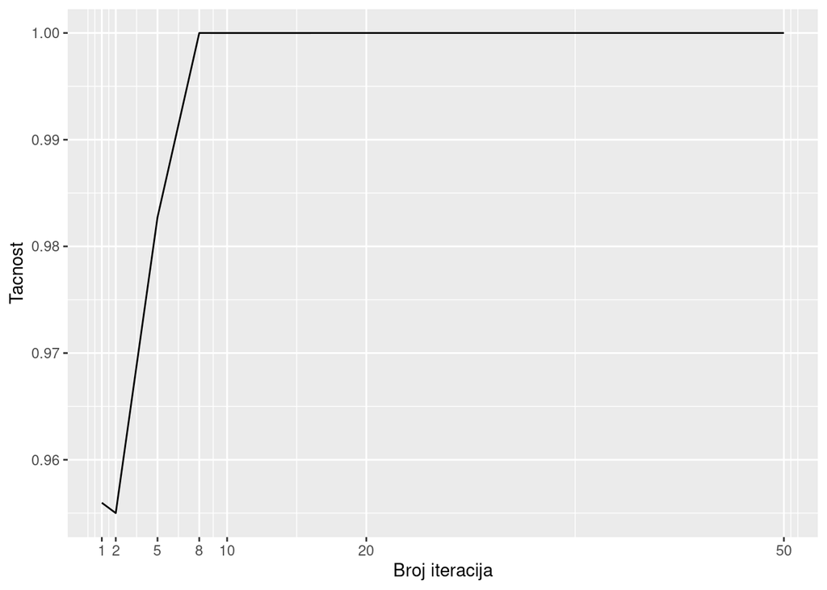

### Poređenje performansi klasifikacionih modela različitog tipa

Izvrsava se klasifikacija modela pomocu tri razlicita algoritma. Najpre se odredjuje vrednost *k* koju postavljamo na 4 kako bi se kreirala 3 skupa za obucavanje i jedan kao validacioni i svaki ce se koristiti kao validacioni u razlicitim iteracijama

```r
k <- 4

# Initialize accuracy vectors
accuracies_log_reg <- c()
accuracies_svm <- c()
accuracies_dec_tree <- c()

violations_partitions <- vector("list", length = k)


parking_violations.split <- sdf_random_split(parking_violations, first = 0.5, second = 0.5, seed = 6)
parking_violations.first <- sdf_random_split(parking_violations.split$first, first = 0.5, second = 0.5, seed = 6)
parking_violations.second <- sdf_random_split(parking_violations.split$second, first = 0.5, second = 0.5, seed = 6)
violations_partitions[[1]] <- parking_violations.first$first
violations_partitions[[2]] <- parking_violations.first$second
violations_partitions[[3]] <- parking_violations.second$first
violations_partitions[[4]] <- parking_violations.second$second

for (i in 1:k) {

  training <- sdf_bind_rows(violations_partitions[-i])
  test <- violations_partitions[[i]]

  log_reg <- ml_logistic_regression(x = training, formula = formula, family = "binomial", max_iter = 20, threshold = 0.5)
  evaluate_log_reg <- ml_evaluate(log_reg, test)
  accuracies_log_reg[i] <- evaluate_log_reg$accuracy()

  svm <- ml_linear_svc(x = training, formula = formula, max_iter = 20, standardization = TRUE)
  evaluate_svm <- ml_evaluate(svm, test)
  accuracies_svm[i] <- evaluate_svm$Accuracy

  dec_tree <- ml_decision_tree_classifier(x = training, formula = formula, max_depth = 5, min_instances_per_node = 1000, impurity = "gini")
  evaluate_dec_tree <- ml_evaluate(dec_tree, test)
  accuracies_dec_tree[i] <- evaluate_dec_tree$Accuracy

}

print(paste("Logistic Regression Mean Accuracy:", mean(accuracies_log_reg)))
print(paste("SVM Mean Accuracy:", mean(accuracies_svm)))
print(paste("Decision Tree Classifier Mean Accuracy:", mean(accuracies_dec_tree)))
```

```
## [1] "Logistic Regression Mean Accuracy: 1"
## [1] "SVM Mean Accuracy: 1"
## [1] "Decision Tree Classifier Mean Accuracy: 1"
```

## Klasterizacija

```r
#Clusterisation1

parking.clusters <- parking_violations %>%
  filter(Vehicle_Year >= 2000 & Vehicle_Year<=2005)  %>%
 group_by(Violation_Code, Vehicle_Year) %>%
  summarise(Count = n())

year.code <- ml_kmeans(
  parking.clusters,
  ~ Vehicle_Year + Violation_Code,
  k = 5,
  max_iter = 10,
  init_mode = "k-means||")
year.code
year.code$model$summary$cluster()

ml_evaluate(year.code, parking_violations %>% select(Vehicle_Year , Violation_Code))

cluster.values <- year.code$model$summary$cluster() %>% collect()
parking.clusters <- parking.clusters %>% collect()
parking.clusters$clust <- as.factor(cluster.values$prediction)

cluster.centers.df <- data.frame(
  year = year.code$centers$Vehicle_Year,
  code = year.code$centers$Violation_Code
)
```

```
## K-means clustering with 5 clusters
##
## Cluster centers:
##   Vehicle_Year Violation_Code
## 1     2003.065      47.413043
## 2     2003.000      89.730337
## 3     2003.013      26.650000
## 4     2003.010      68.794118
## 5     2002.986       8.985915
##
## Within Set Sum of Squared Errors =  not computed.# Source: spark<?> [?? x 1]
##    prediction
##         <int>
##  1          2
##  2          2
##  3          3
##  4          3
##  5          3
##  6          3
##  7          0
##  8          0
##  9          4
## 10          4
## # ℹ more rows
## # A tibble: 1 × 1
##   Silhouette
##        <dbl>
## 1      0.369
```

#### Vizualizacija

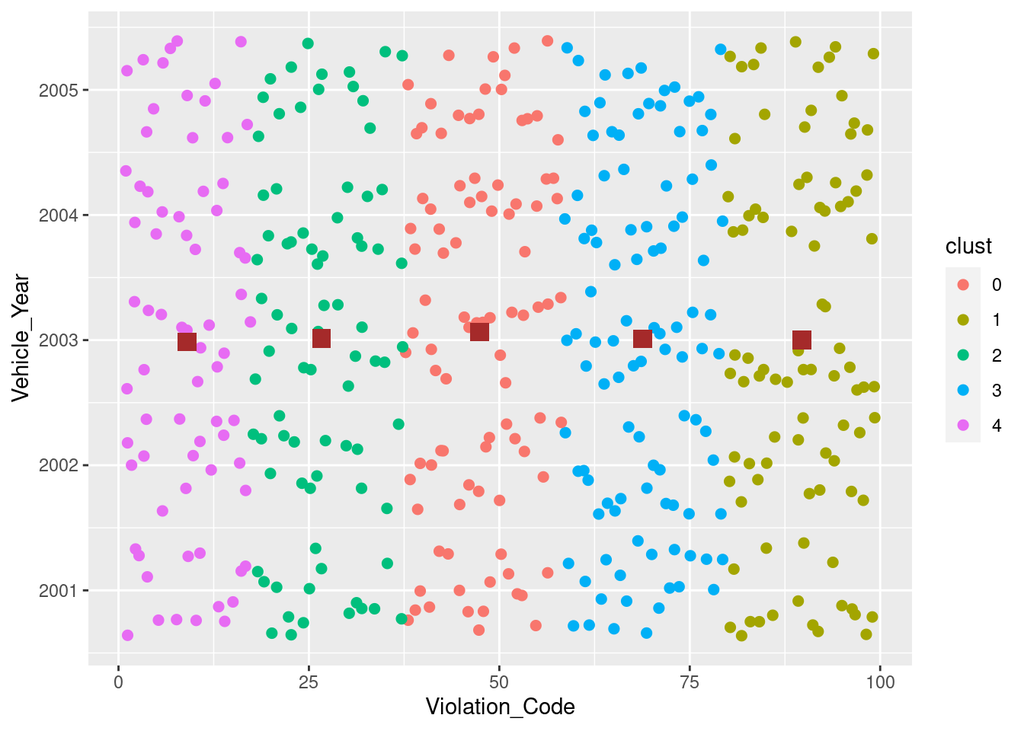

### Klasterizacije agregiranih podataka

#### Sprovođenje klasterizacije

```r
parking.clusters2 <- parking_violations %>%
  group_by(Registration_State,Violation_Code) %>%
  summarise(People_In_State = n(), .groups = "keep") %>%
  filter(People_In_State  > 50000)


year.code2 <- ml_kmeans(
  parking.clusters2,
  ~ People_In_State + Violation_Code,
  k = 3,
  max_iter = 10,
  init_mode = "k-means||")

year.code2
year.code2$model$summary$cluster()

ml_evaluate(year.code2, parking.clusters2 %>% select(People_In_State , Violation_Code))
cluster.values2 <- year.code2$model$summary$cluster() %>% collect()
parking.clusters2 <- parking.clusters2 %>% collect()
parking.clusters2$clust <- as.factor(cluster.values2$prediction)

cluster.centers.df2 <- data.frame(
  location = year.code2$centers$People_In_State,
  code = year.code2$centers$Violation_Code
)
```

```
## K-means clustering with 3 clusters
##
## Cluster centers:
##   People_In_State Violation_Code
## 1        111211.7           43.5
## 2        973392.0           29.5
## 3        450025.8           38.0
##
## Within Set Sum of Squared Errors =  not computed.# Source: spark<?> [?? x 1]
##    prediction
##         <int>
##  1          1
##  2          0
##  3          2
##  4          0
##  5          0
##  6          2
##  7          2
##  8          0
##  9          2
## 10          0
## # ℹ more rows
## # A tibble: 1 × 1
##   Silhouette
##        <dbl>
## 1      0.866
```

#### Vizualizacija

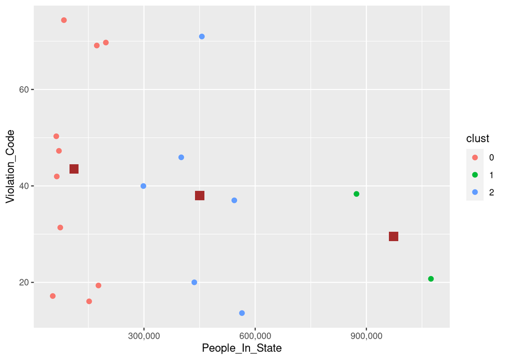